# Final Project

Michael Jenks

```r
library(dplyr)
library(tidyverse)
```

```r
library(ggplot2)
library(DataComputing)
library(party)
```

# Research Question:

Are there any trends we can identify in fantasy football statistics over the last 10 years?

# Notes:

- Fantasy Data and NFL Standings were recorded as of Week 9 in 2023
- Fantasy Points were recorded in PPR format, meaning players get 1 point per reception
- As of 2021, 17 games played per team (Before 2021 - 16)
- QB = Quarterback, RB = Running Back, WR = Wide Reciever, TE = Tight End

To begin we will read the data into the work space:

```r
nflstandings <- read.csv("nflstandings.csv")
fantasydata <- read.csv("fantasydata.csv")

head(nflstandings)
```

|  | Tm | Division | W | L | T | W.L. | Pts | PtsO | PtDif | Year |
| --- | --- | --- | --- | --- | --- | --- | --- | --- | --- | --- |
| 1 | Miami Dolphins | AFC East | 6 | 2 | 0 | 0.750 | 271 | 204 | 67 | 2023 |
| 2 | Buffalo Bills | AFC East | 5 | 3 | 0 | 0.625 | 222 | 136 | 86 | 2023 |
| 3 | New York Jets | AFC East | 4 | 3 | 0 | 0.571 | 126 | 129 | -3 | 2023 |
| 4 | New England Patriots | AFC East | 2 | 6 | 0 | 0.250 | 118 | 208 | -90 | 2023 |
| 5 | Baltimore Ravens | AFC North | 6 | 2 | 0 | 0.750 | 202 | 121 | 81 | 2023 |
| 6 | Cincinnati Bengals | AFC North | 4 | 3 | 0 | 0.571 | 131 | 144 | -13 | 2023 |

```r
head(fantasydata)
```

|  | Rk | Player | Tm | FantPos | G | Yds.Passing | TD.Passes | Int | Rushing.Att | Rush.Yds | Yards.Per.Att | Rush.TD | Receptions | Rec.Yards | Yards.Per.Rec | Rec.TD | Tot.TD | Fantasy.Points | PosRank | OvRank | Year | X | X.1 |
| --- | --- | --- | --- | --- | --- | --- | --- | --- | --- | --- | --- | --- | --- | --- | --- | --- | --- | --- | --- | --- | --- | --- | --- |
| 1 | 1 | Christian McCaffrey | San Francisco 49ers | RB | 8 | 0 | 0 | 0 | 137 | 652 | 4.76 | 9 | 32 | 292 | 9.13 | 4 | 13 | 200.4 | 1 | 1 | 2023 | NA | NA |
| 2 | 2 | Tyreek Hill | Miami Dolphins | WR | 8 | 0 | 0 | 0 | 1 | 14 | 14.00 | 0 | 61 | 1014 | 16.62 | 8 | 8 | 211.8 | 1 | 2 | 2023 | NA | NA |
| 3 | 3 | Raheem Mostert | Miami Dolphins | RB | 8 | 0 | 0 | 0 | 97 | 520 | 5.36 | 10 | 19 | 151 | 7.95 | 2 | 12 | 156.1 | 2 | 3 | 2023 | NA | NA |
| 4 | 4 | Travis Etienne | Jacksonville Jaguars | RB | 8 | 0 | 0 | 0 | 151 | 583 | 3.86 | 7 | 27 | 266 | 9.85 | 1 | 8 | 163.9 | 3 | 4 | 2023 | NA | NA |
| 5 | 5 | A.J. Brown | Philadelphia Eagles | WR | 8 | 0 | 0 | 0 | 0 | 0 | NA | 0 | 60 | 939 | 15.65 | 5 | 5 | 183.9 | 2 | 5 | 2023 | NA | NA |
| 6 | 6 | Josh Allen | Buffalo Bills | QB | 8 | 2165 | 17 | 8 | 36 | 189 | 5.25 | 5 | 0 | 0 | NA | 0 | 5 | 185.5 | 1 | 6 | 2023 | NA | NA |

As an introductory analysis, lets take a look at this year’s fantasy points by position:

```r
fantasy2023 <- fantasydata %>%
  group_by(Year, FantPos) %>%
  filter(Year == 2023) %>%
  summarise(totPointsPerYear = sum(Fantasy.Points)) %>%
  mutate(total = sum(totPointsPerYear)) %>%
  mutate(PropofPoints = totPointsPerYear/total)
fantasy2023
```

| Year | FantPos | totPointsPerYear | total | PropofPoints |
| --- | --- | --- | --- | --- |
| 2023 | QB | 1683.8 | 7597.6 | 0.2216226 |
| 2023 | RB | 2300.2 | 7597.6 | 0.3027535 |
| 2023 | TE | 720.7 | 7597.6 | 0.0948589 |
| 2023 | WR | 2892.9 | 7597.6 | 0.3807650 |

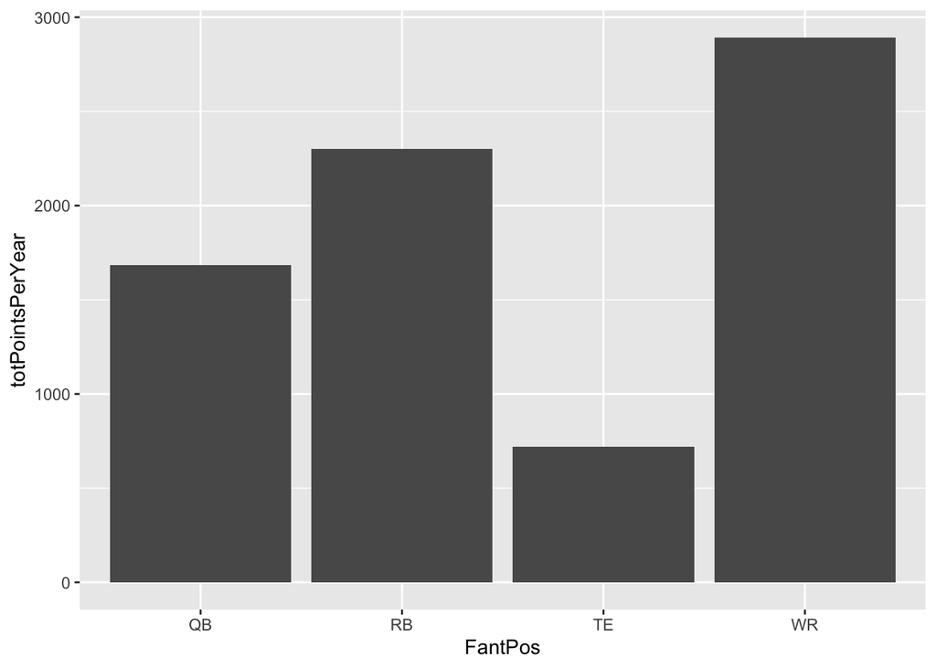

```r
ggplot(data = fantasy2023) +
  geom_col(aes(x = FantPos, y = totPointsPerYear))
```

From this analysis, we see RBs and WRs have carried the majority of fantasy points scored this year. Lets compare this result to the previous 9 years:

```r
fantasyOther9 <- fantasydata %>%
  group_by(Year, FantPos) %>%
  filter(Year != 2023) %>%
  summarise(totPointsPerYear = sum(Fantasy.Points))
fantasyOther9
```

| Year | FantPos | totPointsPerYear |
| --- | --- | --- |
| 2014 | QB | 2243.6 |
| 2014 | RB | 4530.1 |
| 2014 | TE | 1861.3 |
| 2014 | WR | 6443.8 |
| 2015 | QB | 2300.8 |
| 2015 | RB | 4115.3 |
| 2015 | TE | 1940.5 |
| 2015 | WR | 6424.6 |
| 2016 | QB | 3045.0 |
| 2016 | RB | 5051.6 |

[output cut: 26 more lines]

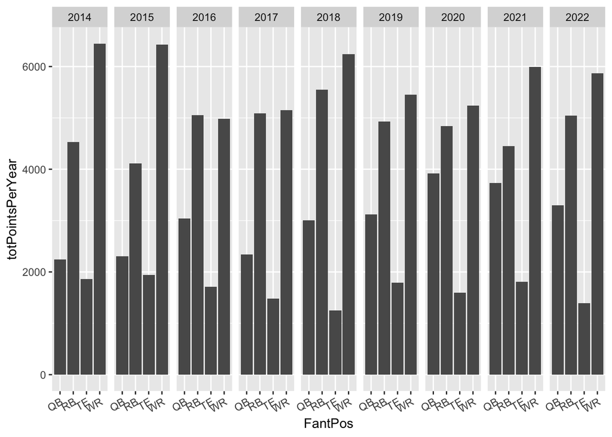

```r
ggplot(data = fantasyOther9) +
  geom_col(aes(x = FantPos, y = totPointsPerYear)) +
  facet_grid(~ Year) +
  theme(axis.text.x = element_text(angle = 30, hjust = 1))
```

The above plots show a similar principle. In terms of fantasy points scored, running backs and wide receivers have been the top 2 scoring positions. In only one year did running backs outscore wide receivers.

Using a join, we will attempt to analyze how wins correlate with fantasy points. First lets get the total number of fantasy points per team per year:

```r
teamPts <- fantasydata %>%
  group_by(Year, Tm) %>%
  summarise(totalFantPoints = sum(Fantasy.Points))
teamPts
```

| Year | Tm | totalFantPoints |
| --- | --- | --- |
| 2014 | Atlanta Falcons | 581.7 |
| 2014 | Baltimore Ravens | 658.1 |
| 2014 | Carolina Panthers | 446.6 |
| 2014 | Chicago Bears | 829.8 |
| 2014 | Cincinnati Bengals | 604.1 |
| 2014 | Dallas Cowboys | 667.1 |
| 2014 | Denver Broncos | 1330.6 |
| 2014 | Detroit Lions | 684.0 |
| 2014 | Green Bay Packers | 1248.0 |
| 2014 | Houston Texans | 504.5 |

[output cut: 278 more lines]

```r
team <- teamPts %>%
  left_join(nflstandings)
team
```

| Year | Tm | totalFantPoints | Division | W | L | T | W.L. | Pts | PtsO | PtDif |
| --- | --- | --- | --- | --- | --- | --- | --- | --- | --- | --- |
| 2014 | Atlanta Falcons | 581.7 | NFC South | 6 | 10 | 0 | 0.375 | 381 | 417 | -36 |
| 2014 | Baltimore Ravens | 658.1 | AFC North | 10 | 6 | 0 | 0.625 | 409 | 302 | 107 |
| 2014 | Carolina Panthers | 446.6 | NFC South | 7 | 8 | 1 | 0.469 | 339 | 374 | -35 |
| 2014 | Chicago Bears | 829.8 | NFC North | 5 | 11 | 0 | 0.313 | 319 | 442 | -123 |
| 2014 | Cincinnati Bengals | 604.1 | AFC North | 10 | 5 | 1 | 0.656 | 365 | 344 | 21 |
| 2014 | Dallas Cowboys | 667.1 | NFC East | 12 | 4 | 0 | 0.750 | 467 | 352 | 115 |
| 2014 | Denver Broncos | 1330.6 | AFC West | 12 | 4 | 0 | 0.750 | 482 | 354 | 128 |
| 2014 | Detroit Lions | 684.0 | NFC North | 11 | 5 | 0 | 0.688 | 321 | 282 | 39 |
| 2014 | Green Bay Packers | 1248.0 | NFC North | 12 | 4 | 0 | 0.750 | 486 | 348 | 138 |
| 2014 | Houston Texans | 504.5 | AFC South | 9 | 7 | 0 | 0.563 | 372 | 307 | 65 |

[output cut: 278 more lines]

Using this table we’ll combine all the teams from every year into one row for each, counting their wins and fantasy points:

```r
winsPoints <- team %>%
  group_by(Tm) %>%
  summarise(totalWins = sum(W), FanPts = sum(totalFantPoints))
winsPoints
```

| Tm | totalWins | FanPts |
| --- | --- | --- |
| Arizona Cardinals | 59 | 4289.2 |
| Atlanta Falcons | 64 | 5322.9 |
| Baltimore Ravens | 68 | 3215.2 |
| Buffalo Bills | 76 | 4586.0 |
| Carolina Panthers | 69 | 4436.9 |
| Chicago Bears | 58 | 3561.9 |
| Cincinnati Bengals | 69 | 4842.1 |
| Cleveland Browns | 47 | 3032.7 |
| Dallas Cowboys | 91 | 5989.0 |
| Denver Broncos | 71 | 4266.5 |

[output cut: 27 more lines]

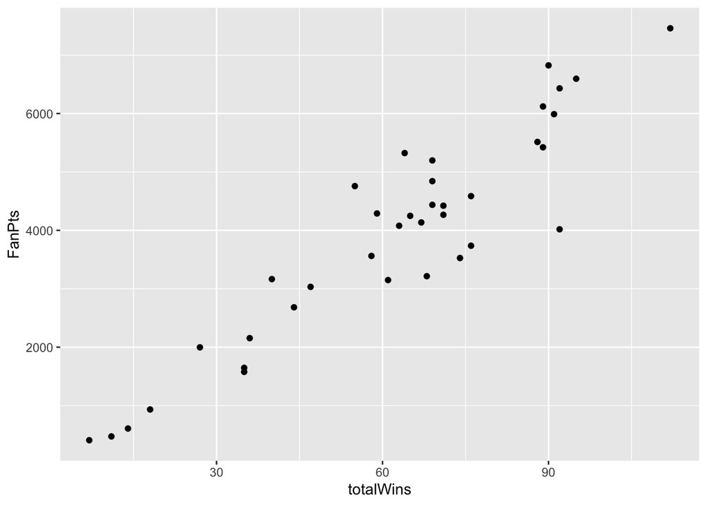

```r
ggplot(data = winsPoints, aes(x = totalWins,y = FanPts)) +
  geom_point()
```

Clearly, we see with this plot that wins have a positive relationship with fantasy points. We can also calculate the correlation to quantify this result:

```r
cor(winsPoints$totalWins, winsPoints$FanPts)
```

```
## [1] 0.9322288
```

This correlation is very high and positive, further proving the strong, positive relationship seen in the plot.

We can also look at this plot through each division, since each team having their own aesthetic on one plot can create data that is hard to read (i.e. making each team a color):

```r
divPoints <- team %>%
  group_by(Division) %>%
  summarise(totalWins = sum(W), FanPts = sum(totalFantPoints))
divPoints
```

| Division | totalWins | FanPts |
| --- | --- | --- |
| AFC East | 279 | 13987.5 |
| AFC North | 272 | 16603.3 |
| AFC South | 248 | 15191.9 |
| AFC West | 319 | 21568.5 |
| NFC East | 284 | 16750.9 |
| NFC North | 304 | 20361.1 |
| NFC South | 292 | 21781.2 |
| NFC West | 289 | 18576.8 |

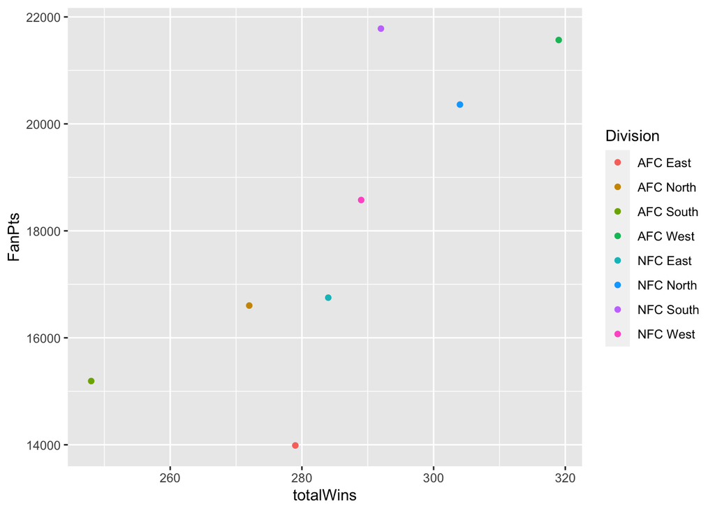

```r
ggplot(data = divPoints) +
  geom_point(aes(x = totalWins, y = FanPts, color = Division))
```

Once again, we see a positive relationship between wins and fantasy points scored per division. There appears to be a few unusual points. There could be many reasons for this. The most likely is that a team performed poorly compared to the rest of the division, inflating or deflating the results.

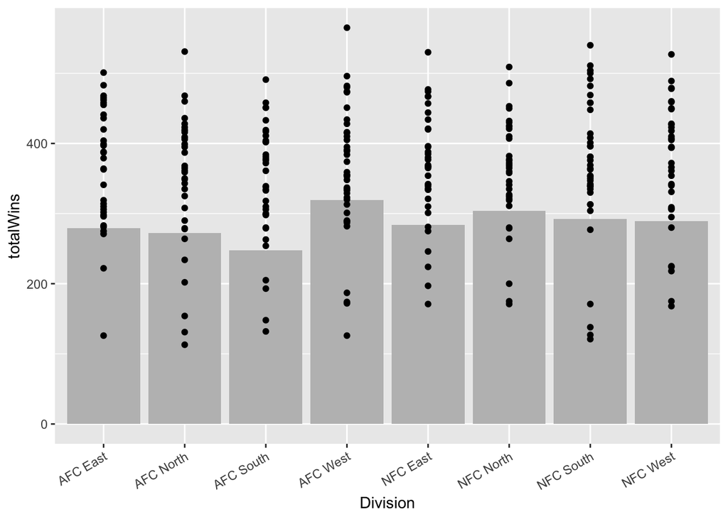

```r
divPoints %>%
  ggplot(aes(x = Division, y = totalWins)) +
  geom_bar(stat = "identity", fill = "gray", color = NA) +
  geom_point(data = team, aes(x = Division, y = Pts)) +
  theme(axis.text.x = element_text(angle = 30, hjust = 1))
```

The layered graphic above shows the number of wins each division recorded since 2014. The dots represent the number of points scored for each team in that division accounting for every year. From this graphic, we see that the AFC West division seems to have the most wins since 2014 and when looking at the dots, we see that the AFC west has been one of the best at scoring points. Overall they were much more consistent than say the AFC North and AFC East whos ceilings were lower than the AFC West in terms of points scored.

Let’s take a look at fantasy stats of players who’s name starts with a certain letter. Lets select A, B, and C.

```r
pattern <- "^A."
StartwA <- fantasydata %>%
  filter(grepl(pattern, Player))
StartwA
```

| Rk | Player | Tm | FantPos | G | Yds.Passing | TD.Passes | Int | Rushing.Att | Rush.Yds | Yards.Per.Att | Rush.TD | Receptions | Rec.Yards | Yards.Per.Rec | Rec.TD | Tot.TD | Fantasy.Points | PosRank | OvRank | Year | X | X.1 |
| --- | --- | --- | --- | --- | --- | --- | --- | --- | --- | --- | --- | --- | --- | --- | --- | --- | --- | --- | --- | --- | --- | --- |
| 5 | A.J. Brown | Philadelphia Eagles | WR | 8 | 0 | 0 | 0 | 0 | 0 | NA | 0 | 60 | 939 | 15.65 | 5 | 5 | 183.9 | 2 | 5 | 2023 | NA | NA |
| 30 | Adam Thielen | Carolina Panthers | WR | 7 | 0 | 0 | 0 | 1 | 6 | 6.00 | 0 | 57 | 581 | 10.19 | 4 | 4 | 141.7 | 9 | 30 | 2023 | NA | NA |
| 34 | Amon-Ra St. Brown | Detroit Lions | WR | 7 | 0 | 0 | 0 | 1 | 4 | 4.00 | 0 | 57 | 665 | 11.67 | 3 | 3 | 139.9 | 11 | 34 | 2023 | NA | NA |
| 44 | Alvin Kamara | New Orleans Saints | RB | 5 | 0 | 0 | 0 | 86 | 320 | 3.72 | 2 | 39 | 228 | 5.85 | 1 | 3 | 113.8 | 18 | 44 | 2023 | NA | NA |
| 6 | Austin Ekeler | Los Angeles Chargers | RB | 17 | 0 | 0 | 0 | 204 | 915 | 4.49 | 13 | 107 | 722 | 6.75 | 5 | 18 | 372.7 | 4 | 6 | 2022 | NA | NA |
| 13 | A.J. Brown | Philadelphia Eagles | WR | 17 | 0 | 0 | 0 | 0 | 0 | NA | 0 | 88 | 1496 | 17.00 | 11 | 11 | 299.6 | 4 | 13 | 2022 | NA | NA |
| 24 | Amari Cooper | Cleveland Browns | WR | 17 | 0 | 0 | 1 | 0 | 0 | NA | 0 | 78 | 1160 | 14.87 | 9 | 9 | 246.0 | 8 | 24 | 2022 | NA | NA |
| 26 | Aaron Jones | Green Bay Packers | RB | 17 | 0 | 0 | 0 | 213 | 1121 | 5.26 | 2 | 59 | 395 | 6.69 | 5 | 7 | 248.6 | 11 | 26 | 2022 | NA | NA |
| 27 | Amon-Ra St. Brown | Detroit Lions | WR | 16 | 0 | 0 | 0 | 9 | 95 | 10.56 | 0 | 106 | 1161 | 10.95 | 6 | 6 | 267.6 | 9 | 27 | 2022 | NA | NA |
| 54 | Alvin Kamara | New Orleans Saints | RB | 15 | 0 | 0 | 0 | 223 | 897 | 4.02 | 2 | 57 | 490 | 8.60 | 2 | 4 | 211.7 | 18 | 54 | 2022 | NA | NA |

[output cut: 54 more lines]

```r
pattern <- "^B."
StartwB <- fantasydata %>%
  filter(grepl(pattern, Player))
StartwB
```

| Rk | Player | Tm | FantPos | G | Yds.Passing | TD.Passes | Int | Rushing.Att | Rush.Yds | Yards.Per.Att | Rush.TD | Receptions | Rec.Yards | Yards.Per.Rec | Rec.TD | Tot.TD | Fantasy.Points | PosRank | OvRank | Year | X | X.1 |
| --- | --- | --- | --- | --- | --- | --- | --- | --- | --- | --- | --- | --- | --- | --- | --- | --- | --- | --- | --- | --- | --- | --- |
| 22 | Brian Robinson Jr. | Washington Commanders | RB | 8 | 0 | 0 | 0 | 95 | 384 | 4.04 | 4 | 13 | 133 | 10.23 | 2 | 6 | 102.7 | 9 | 22 | 2023 | NA | NA |
| 37 | Bijan Robinson | Atlanta Falcons | RB | 8 | 0 | 0 | 0 | 92 | 466 | 5.07 | 1 | 26 | 189 | 7.27 | 2 | 3 | 107.5 | 14 | 37 | 2023 | NA | NA |
| 38 | Breece Hall | New York Jets | RB | 7 | 0 | 0 | 0 | 78 | 443 | 5.68 | 2 | 19 | 189 | 9.95 | 1 | 3 | 100.2 | 15 | 38 | 2023 | NA | NA |
| 45 | Brandon Aiyuk | San Francisco 49ers | WR | 7 | 0 | 0 | 0 | 0 | 0 | NA | 0 | 35 | 620 | 17.71 | 2 | 2 | 109.0 | 14 | 45 | 2023 | NA | NA |
| 50 | Brock Purdy | San Francisco 49ers | QB | 8 | 2033 | 12 | 5 | 26 | 107 | 4.12 | 2 | 0 | 0 | NA | 0 | 2 | 138.0 | 10 | 50 | 2023 | NA | NA |
| 37 | Brandon Aiyuk | San Francisco 49ers | WR | 17 | 0 | 0 | 0 | 2 | 23 | 11.50 | 0 | 78 | 1015 | 13.01 | 8 | 8 | 227.8 | 15 | 37 | 2022 | NA | NA |
| 56 | Brandin Cooks | Houston Texans | WR | 16 | 0 | 0 | 0 | 2 | 21 | 10.50 | 0 | 90 | 1037 | 11.52 | 6 | 6 | 231.8 | 20 | 56 | 2021 | NA | NA |
| 44 | Brandin Cooks | Houston Texans | WR | 15 | 0 | 0 | 0 | 0 | 0 | NA | 0 | 81 | 1150 | 14.20 | 6 | 6 | 232.0 | 16 | 44 | 2020 | NA | NA |
| 27 | Ben Roethlisberger | Pittsburgh Steelers | QB | 16 | 5129 | 34 | 16 | 31 | 98 | 3.16 | 3 | 1 | -1 | -1.00 | 0 | 3 | 341.9 | 3 | 27 | 2018 | NA | NA |
| 34 | Brandin Cooks | Los Angeles Rams | WR | 16 | 0 | 0 | 0 | 10 | 68 | 6.80 | 1 | 80 | 1204 | 15.05 | 5 | 6 | 243.2 | 13 | 34 | 2018 | NA | NA |

[output cut: 9 more lines]

```r
pattern <- "^C."
StartwC <- fantasydata %>%
  filter(grepl(pattern, Player))
StartwC
```

| Rk | Player | Tm | FantPos | G | Yds.Passing | TD.Passes | Int | Rushing.Att | Rush.Yds | Yards.Per.Att | Rush.TD | Receptions | Rec.Yards | Yards.Per.Rec | Rec.TD | Tot.TD | Fantasy.Points | PosRank | OvRank | Year | X | X.1 |
| --- | --- | --- | --- | --- | --- | --- | --- | --- | --- | --- | --- | --- | --- | --- | --- | --- | --- | --- | --- | --- | --- | --- |
| 1 | Christian McCaffrey | San Francisco 49ers | RB | 8 | 0 | 0 | 0 | 137 | 652 | 4.76 | 9 | 32 | 292 | 9.13 | 4 | 13 | 200.4 | 1 | 1 | 2023 | NA | NA |
| 31 | CeeDee Lamb | Dallas Cowboys | WR | 7 | 0 | 0 | 0 | 4 | 33 | 8.25 | 0 | 46 | 633 | 13.76 | 3 | 3 | 130.6 | 10 | 31 | 2023 | NA | NA |
| 58 | Courtland Sutton | Denver Broncos | WR | 8 | 0 | 0 | 0 | 0 | 0 | NA | 0 | 33 | 380 | 11.52 | 6 | 6 | 103.0 | 22 | 58 | 2023 | NA | NA |
| 60 | Cole Kmet | Chicago Bears | TE | 8 | 0 | 0 | 0 | 2 | 1 | 0.50 | 0 | 35 | 319 | 9.11 | 3 | 3 | 85.0 | 7 | 60 | 2023 | NA | NA |
| 3 | Christian McCaffrey | San Francisco 49ers | RB | 17 | 34 | 1 | 0 | 244 | 1139 | 4.67 | 8 | 85 | 741 | 8.72 | 5 | 13 | 356.4 | 2 | 3 | 2022 | NA | NA |
| 16 | CeeDee Lamb | Dallas Cowboys | WR | 17 | 0 | 0 | 0 | 10 | 47 | 4.70 | 0 | 107 | 1359 | 12.70 | 9 | 9 | 301.6 | 6 | 16 | 2022 | NA | NA |
| 30 | Christian Kirk | Jacksonville Jaguars | WR | 17 | 0 | 0 | 0 | 5 | 11 | 2.20 | 0 | 84 | 1108 | 13.19 | 8 | 8 | 241.9 | 11 | 30 | 2022 | NA | NA |
| 57 | Cole Kmet | Chicago Bears | TE | 17 | 0 | 0 | 0 | 2 | 9 | 4.50 | 0 | 50 | 544 | 10.88 | 7 | 7 | 147.3 | 7 | 57 | 2022 | NA | NA |
| 58 | Cooper Kupp | Los Angeles Rams | WR | 9 | 0 | 0 | 0 | 9 | 52 | 5.78 | 1 | 75 | 812 | 10.83 | 6 | 7 | 201.4 | 22 | 58 | 2022 | NA | NA |
| 59 | Chris Olave | New Orleans Saints | WR | 15 | 0 | 0 | 0 | 0 | 0 | NA | 0 | 72 | 1042 | 14.47 | 4 | 4 | 198.2 | 23 | 59 | 2022 | NA | NA |

[output cut: 33 more lines]

Summary Statistics for Each

```r
StartwA %>%
  summarise(avgPtsA = mean(Fantasy.Points))
```

| avgPtsA |
| --- |
| 267.3922 |

```r
StartwB %>%
  summarise(avgPtsB = mean(Fantasy.Points))
```

| avgPtsB |
| --- |
| 220.4684 |

```r
StartwC %>%
  summarise(avgPtsC = mean(Fantasy.Points))
```

| avgPtsC |
| --- |
| 237.5233 |

From this introductory analysis, we can conclude that over the past 10 years, Players names who starts with A have had more success in fantasy football than players with names starting with B or C.

For the final part of the project, lets use machine learning to see what variables are having the most impact on our response variable, fantasy points.

```r
fantasydata <- fantasydata %>%
  mutate(totYards = Rush.Yds + Yds.Passing + Rec.Yards)
```

```r
fantasyModel <- lm(Fantasy.Points ~ Tot.TD + factor(FantPos) + totYards + Receptions, data = fantasydata)
fantasyModel$coefficients
```

```
##       (Intercept)            Tot.TD factor(FantPos)RB factor(FantPos)TE
##      -34.95207125        6.77952596       49.87393843       34.85970553
## factor(FantPos)WR          totYards        Receptions
##       38.40153572        0.07388636        1.23694005
```

```r
summary(fantasyModel)
```

```
##
## Call:
## lm(formula = Fantasy.Points ~ Tot.TD + factor(FantPos) + totYards +
##     Receptions, data = fantasydata)
##
## Residuals:
##     Min      1Q  Median      3Q     Max
## -62.384  -4.156   0.051   3.456  83.046
##
## Coefficients:
##                    Estimate Std. Error t value Pr(>|t|)
## (Intercept)       -34.95207    5.02277  -6.959 9.12e-12 ***
## Tot.TD              6.77953    0.14421  47.011  < 2e-16 ***
## factor(FantPos)RB  49.87394    4.45130  11.204  < 2e-16 ***
## factor(FantPos)TE  34.85971    5.34911   6.517 1.53e-10 ***
## factor(FantPos)WR  38.40154    5.20962   7.371 5.71e-13 ***
## totYards            0.07389    0.00115  64.234  < 2e-16 ***
## Receptions          1.23694    0.02632  47.003  < 2e-16 ***
## ---
## Signif. codes:  0 '***' 0.001 '**' 0.01 '*' 0.05 '.' 0.1 ' ' 1
##
## Residual standard error: 11.14 on 593 degrees of freedom
## Multiple R-squared:  0.9746, Adjusted R-squared:  0.9744
## F-statistic:  3794 on 6 and 593 DF,  p-value: < 2.2e-16
```